# R, VS Code, Quarto, and AI Tools for DOE

AGST 50104: Experimental Design

Dr. Samuel B Fernandes

2026-01-01

## Learning Objectives

By the end of this lecture, you should be able to:

- Navigate VS Code and create workspaces for reproducible research
- Understand what GitHub Copilot is and why it’s useful for learning
- Use AI tools effectively for statistical programming with proper prompting
- Write effective prompts for AI assistance

# Why These Tools Matter

## Reproducibility in Research

- **The Problem:** “It worked on my computer” is not acceptable in science
- **The Solution:** Quarto documents combine code, analysis, and narrative in one file
- **Result:** Anyone can re-run your analysis and get the same results
- **Benefit for you:** Your future self will thank you when revising a thesis chapter

**Reproducible Research = Transparent Science**

When you publish, reviewers and readers can verify your work. When you graduate, your advisor can extend your research.

## The Modern Research Workflow

[figure not shown]

- R handles the analysis
- Quarto handles the communication
- AI tools help with both

# VS Code Setup for R & Quarto

## Why VS Code for Data Science?

**Key Benefits:**

- Free & open-source
- Multi-language support
- **Integrated AI** (GitHub Copilot)
- Built-in Git
- Works everywhere

**For This Course:**

- Industry-standard workflow
- AI assistance built-in
- Easy GitHub collaboration
- Professional skill development

**Tip**

**Alternative:** RStudio also works well (see supplemental guide)

## Essential VS Code Extensions

**Install These Three (Required):**

### R Extension

- **By:** REditorSupport
- R code execution
- Syntax highlighting

### Quarto

- **By:** Quarto.org
- Render `.qmd` files
- Live preview

### GitHub Copilot

- **AI assistance**
- Code suggestions
- Free for students

**How to Install:** Extensions icon (Ctrl/Cmd+Shift+X) → Search → Install

## VS Code Interface Tour

**Five Main Areas:**

1. **Activity Bar** (far left)
   - Explorer (files)
   - Search
   - Source Control (Git)
   - Extensions
   - Copilot Chat
2. **Side Bar** (left)
   - File tree
   - Search results
   - Git changes
3. **Editor** (center)
   - Your code/documents
   - Multiple tabs
   - Split view
4. **Panel** (bottom)
   - **Terminal** (run R commands)
   - **Output** (Quarto render logs)
   - **Problems** (errors/warnings)
   - **Debug console**
5. **Status Bar** (very bottom)
   - Git branch
   - File type
   - R/Python interpreter

## Working with R in VS Code

**Open R Terminal:**

1. **Ctrl/Cmd + `**
2. Type `R` + Enter
3. Interactive R session!

**Quick test:**

```r
2 + 2
x <- 10
x * 5
```

**Run Code from Files:**

- Create `.R` or `.qmd` file
- Select code
- **Ctrl/Cmd + Enter**

**Tip**

**Pro tip:** Keep R terminal open while coding

## Creating a Workspace (VS Code “Projects”)

**Workspaces** in VS Code are like R Projects in RStudio—they keep all your files organized and settings consistent.

**Create your course workspace:**

1. File → Open Folder (Mac: Open…)
2. Navigate to Documents or Desktop
3. Create new folder: `doe_course`
4. Click “Select Folder” / “Open”

**Recommended folder structure:**

```
doe_course/
  ├── data/          # Your datasets
  ├── scripts/       # R scripts
  ├── analyses/      # Quarto documents
  ├── figures/       # Output plots
  └── README.md      # Project notes
```

# GitHub Account & Copilot Setup

## Why GitHub?

**GitHub provides:**

- **Version control** for your code (like “track changes” for scripts)
- **Collaboration** tools (share code, get feedback)
- **Portfolio** of your work (impress future employers!)
- **Free GitHub Copilot** with your .edu email
- **Backup** of all your projects in the cloud

**What is GitHub Copilot?**

- AI pair programmer
- Suggests code as you type
- Explains code in plain English
- Debugs errors
- Generates test data
- **Free for students!**

# Using GitHub Copilot for Statistics

## What Copilot Can Do for You

**Code Generation:**

- Write functions from comments
- Complete code as you type
- Suggest entire code blocks
- Create plots from descriptions

**Code Explanation:**

- Explain what code does
- Translate between languages
- Suggest improvements
- Find bugs

**Statistical Tasks:**

- Run ANOVA, t-tests, regression
- Create visualizations
- Simulate data
- Apply transformations

**Learning Aid:**

- “How do I…?” questions
- “Why does this error occur?”
- “What’s the difference between…?”

## Using Copilot: Two Modes

**Mode 1: Inline Suggestions (as you type)**

```r
# Type this comment and wait:
# Create a data frame of 4 nitrogen treatments with 6 reps each

# Copilot suggests (in gray):
treatments <- data.frame(
  plot = 1:24,
  nitrogen = rep(c("Control", "N50", "N100", "N150"), each = 6)
)
```

Press **Tab** to accept | **Esc** to reject | **Alt/Option+]** for next suggestion

**Mode 2: Copilot Chat (conversations)**

1. Click Copilot Chat icon in Activity Bar (left)
2. Or press **Ctrl/Cmd + I** for inline chat
3. Get explanations, code, debugging help

## Copilot for Statistics: Essential Prompts

**When writing code:**

- “Generate a completely randomized design with 4 treatments and 5 replicates”
- “Create a ggplot boxplot of yield by treatment”
- “Run a one-way ANOVA on this data frame”
- “Check ANOVA assumptions with diagnostic plots”
- “Perform Tukey’s HSD post-hoc test”

**When learning:**

- “Explain what aov() does in R”
- “What’s the difference between Type I and II sums of squares?”
- “Why do I get this error: object not found”
- “How do I check for normality in residuals?”

# Effective AI Prompting

## The Anatomy of a Good Prompt

**Good prompts** = Clear context + Specific request + Expected format

**Formula:**

```
Context: What data/situation you have
Task: What you want to accomplish
Constraints: Any requirements or preferences
Format: How you want the output
```

**Example:**

**Bad prompt:** > “plot the data”

❌ What data?  
❌ What kind of plot?  
❌ What variables?

**Good prompt:** > “Create a ggplot boxplot of wheat yield (kg/ha) by nitrogen treatment. The data frame is called `trial_data` with columns `treatment` and `yield`. Use a minimal theme and label axes clearly.”

✅ Specific tool (ggplot)  
✅ Plot type (boxplot)  
✅ Variables identified  
✅ Data structure given  
✅ Style preferences

## Prompting Strategies for Statistics

**Strategy 1: Start Simple, Then Refine**

1. First prompt: “Load the tidyverse package”
2. Second prompt: “Create a data frame with treatment and yield columns”
3. Third prompt: “Calculate mean yield by treatment”
4. Fourth prompt: “Create a bar plot of mean yields”

**Why this works:** Each step builds on the last. Easier to debug.

**Strategy 2: Provide Example Data Structure**

```r
# Instead of: "analyze my data"
# Do this:

# My data looks like this:
# treatment  yield  block
# Control    2400   1
# N50        2650   1
# N100       2900   1

# Run a two-way ANOVA with treatment and block as factors
```

**Why this works:** Copilot sees your actual variable names and structure.

## Examples: Bad vs. Good Prompts

**❌ Bad Prompts:**

```r
# Do stats
```

- Too vague

```r
# Plot
```

- No context

```r
# Fix this
```

- Doesn’t say what’s wrong

```r
# ANOVA
```

- Missing data structure

**✅ Good Prompts:**

```r
# Perform one-way ANOVA on yield
# by treatment using aov()
```

```r
# Create ggplot histogram of
# residuals from model_fit.
# Add normal curve overlay.
```

```r
# This code gives "object not found"
# error. I'm trying to access the
# yield column. Data frame is df.
```

```r
# Run ANOVA on df with response =
# yield, factor = treatment. Then
# check assumptions with diagnostic
# plots.
```

## When to Use (and Not Use) AI

**✅ Good Uses:**

- Learning syntax
- Debugging errors
- Creating visualizations
- Exploring approaches
- Getting unstuck

**❌ Don’t Use For:**

- Understanding **why**
- Interpreting results
- Research decisions
- Graded assessments
- Replacing learning

**Caution**

**Rule:** Always review & test AI code!

## Copilot Pro Tips for This Course

**Tip 1: Give context with comments**

```r
# Data: 24 plots, 4 treatments, completely randomized design
# Response: wheat yield (kg/ha)
# Run ANOVA and check assumptions
```

Copilot uses ALL nearby code as context.

**Tip 2: Use Copilot Chat for explanations**

When you see unfamiliar code, highlight it → Right-click → “Copilot: Explain This”

**Tip 3: Ask for alternatives**

> “Show me 3 different ways to create a randomized block design in R”

**Tip 4: Request code with comments**

> “Generate a CRD randomization and add comments explaining each step”

**Tip 5: Verify statistical appropriateness**

> “Is a one-way ANOVA appropriate for this experimental design? Explain why or why not.”

# AI Tools Comparisons/suggestions

## Core Coding & Statistics

| **Task** | **Best Tool** | **Why** | **Cost** |
| --- | --- | --- | --- |
| **Inline code suggestions** | GitHub Copilot | Native VS Code integration; learns your style | Free (students) |
| **Statistical explanations** | ChatGPT (GPT-4) | Best at explaining concepts in plain English | Free tier or $20/mo |
| **R-specific help** | Claude 3 | Strong with data science; long context window | Free tier or $20/mo |
| **Complex reasoning** | Claude 3 Opus | Best for experimental design decisions | $20/mo (optional) |
| **Quick debugging** | Copilot Chat | Instant, in-editor; sees your full code | Free (students) |
| **Learning statistics** | ChatGPT/Claude | Conversational; good at analogies | Free tiers available |
| **Code review** | Claude | Detailed feedback; catches subtle issues | Free tier available |

## Specialized AI Tools for Agriculture & Data

| **Task** | **Best Tool** | **Why** | **Cost** |
| --- | --- | --- | --- |
| **Data visualization** | Gamma AI | Convert raw data/tables into beautiful interactive dashboards | Free tier or $12/mo |
| **Visual design** | Napkin | Transform text/data into diagrams, charts, infographics | Free tier available |
| **Data analysis reports** | NotebookLM | AI notebook that synthesizes & organizes information | Free (Google account) |
| **Statistical plots** | Plotly Copilot | Smart suggestions for best chart types | Free tier or paid |
| **Latex equations** | ChatGPT | Excellent at math formatting & derivations | Free tier available |
| **Presentation design** | Tome | AI-powered storytelling with slides & visuals | Free tier or $10/mo |
| **Data exploration** | ChatGPT with Code Interpreter | Execute & visualize code output inline | $20/mo (GPT-4) |

## AI Tool Strengths & Weaknesses

**GitHub Copilot**

✅ Fast inline suggestions  
✅ Integrated in VS Code  
✅ Learns from your code  
✅ Free for students  
❌ Can’t explain concepts deeply  
❌ Occasionally wrong with stats

**ChatGPT (OpenAI)**

✅ Best for learning concepts  
✅ Great explanations  
✅ Conversational  
✅ Free tier (GPT-3.5)  
❌ Sometimes verbose  
❌ GPT-5 requires subscription

**Claude (Anthropic)**

✅ Strong with R/Python  
✅ Very accurate with statistics  
✅ Long conversations (memory)  
✅ Free tier available  
❌ Slower than Copilot  
❌ Not integrated in editor

**Gemini (Google)**

✅ Fast responses  
✅ Free and unlimited  
✅ Integrated with Google products  
❌ Less accurate for statistics  
❌ Weaker at R coding

## Copilot in Action: Example 1

**Task:** Create a completely randomized design

**What you type:**

```r
# Generate a completely randomized design
# 4 treatments: Control, Low, Medium, High
# 6 replicates per treatment
# Assign to 24 plots randomly
```

**Copilot suggests:**

```r
set.seed(2026)
treatments <- rep(c("Control", "Low", "Medium", "High"), each = 6)
randomized <- sample(treatments)
crd_design <- data.frame(
  plot = 1:24,
  treatment = randomized
)
```

**Your job:** Review, test, understand. Press Tab to accept!

## Copilot in Action: Example 2

**Task:** Visualize the experimental design

**What you type:**

```r
# Create a field layout visualization
# Show treatments in a 4x6 grid with colors
```

**Copilot + Your refinement:**

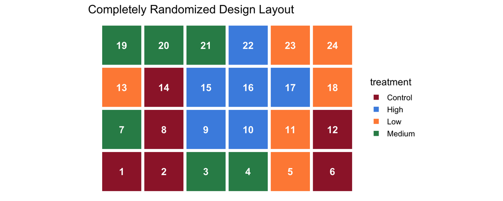

Figure 1: CRD field layout

```r
# Add coordinates
crd_design <- crd_design |>
  mutate(
    row = rep(1:4, each = 6),
    col = rep(1:6, times = 4)
  )

# Create visualization
ggplot(crd_design, aes(x = col, y = row, fill = treatment)) +
  geom_tile(color = "white", linewidth = 2) +
  geom_text(aes(label = plot), color = "white", size = 5, fontface = "bold") +
  scale_fill_manual(values = c("Control" = "#9D2235",
                                "Low" = "#FF8C42",
                                "Medium" = "#2E8B57",
                                "High" = "#4A90E2")) +
  labs(title = "Completely Randomized Design Layout") +
  theme_void(base_size = 14) +
  coord_equal()
```

## ChatGPT/Claude Example: Conceptual Help

**Question to ChatGPT:**

> “I’m designing a fertilizer experiment with 4 nitrogen rates. I have 24 plots in a field that has a known fertility gradient from north to south. Should I use a completely randomized design or a randomized complete block design? Explain the trade-offs.”

**ChatGPT response (summary):**

> “Use a **Randomized Complete Block Design (RCBD)** for this scenario:
> - **Why**: The fertility gradient is a known source of variation. Blocking by location (e.g., 6 blocks running east-west) removes this variation from experimental error.
> - **Trade-off**: Slightly more complex analysis, but much better precision.
> - **CRD would**: Ignore the gradient, inflating error and reducing power to detect treatment differences. Recommendation: Create 6 blocks (north to south), each containing all 4 treatments randomly assigned.”

**Your takeaway:** AI helps you think through experimental design decisions!

# Summary & Key Takeaways

## What We Learned Today

- **VS Code** is a powerful, free IDE for data science with R and Quarto support
- **GitHub Copilot** (free for students) provides AI-powered coding assistance
- **Workspaces** organize projects like R Projects in RStudio
- **Quarto documents** combine code, text, and output for reproducible reports
- **tidyverse** provides readable, powerful tools for data manipulation and visualization
- **AI tools** (Copilot, ChatGPT, Claude) accelerate learning and coding
- **Good prompts** = context + specific task + format
- **Randomization** in R is straightforward with `sample()` and `set.seed()`

## Resources & References

**Software & Setup:**

- **R:** cran.r-project.org
- **VS Code:** code.visualstudio.com
- **Quarto:** quarto.org
- **GitHub:** github.com
- **VS Code R Extension:** [marketplace.visualstudio.com](https://marketplace.visualstudio.com/items?itemName=REditorSupport.r)

**Learning Materials:**

- **R for Data Science (2e):** r4ds.hadley.nz
- **ggplot2 book:** ggplot2-book.org
- **Quarto Guide:** [quarto.org/docs/guide](https://quarto.org/docs/guide/)
- **GitHub Copilot Docs:** docs.github.com/copilot
- **VS Code Tips:** code.visualstudio.com/docs

## Resources & References

**AI Tools:**

- **GitHub Copilot:** github.com/features/copilot
- **ChatGPT:** chat.openai.com
- **Claude:** claude.ai
- **Gemini:** gemini.google.com

**Getting Help:**

- **Stack Overflow:** stackoverflow.com
- **RStudio Community:** community.rstudio.com
- **Copilot in VS Code:** Press Ctrl/Cmd+I for inline chat anytime
- **Office Hours:** See syllabus for schedule